# Продажа квартир в Санкт-Петербурге — анализ рынка недвижимости

### Предобработка данных

#### Устранение пропусков

Для начала нужно разобраться с пропусками, которых как видно из общей информации немало. Где-то умышленные, где-то случайные, но когда их очень много они могут существенно исказить результаты исследований. На данном этапе для удобства дальнейшей обработки заменим пропуски в столбцах с высотой потолков и количеством балконов на нули.

```python
data[['ceiling_height', 'balcony']].fillna(0)
```

|  | ceiling_height | balcony |
| --- | --- | --- |
| 0 | 2.70 | 0.0 |
| 1 | 0.00 | 2.0 |
| 2 | 0.00 | 0.0 |
| 3 | 0.00 | 0.0 |
| 4 | 3.03 | 0.0 |
| ... | ... | ... |
| 23694 | 3.70 | 0.0 |
| 23695 | 0.00 | 0.0 |
| 23696 | 0.00 | 0.0 |
| 23697 | 3.00 | 2.0 |
| 23698 | 2.50 | 0.0 |

23699 rows × 2 columns

К содержанию

#### Работа с форматом данных

Начнем со столбца где хранятся даты подачи объявления. Они имеют тип object, который не пригоден для вычислений. Исправим его на формат datetime.

```python
data['first_day_exposition']=pd.to_datetime(data['first_day_exposition'], format='%Y-%m-%dT%H:%M:%S')
```

Другой столбец (is_apartment) также содержит данные типа object, хотя должен состоять из типа bool(ложь или истина). Заменим нули на False и изменим формат.

```python
data.loc[data['is_apartment']==0,'is_apartment']=False
data['is_apartment']=data['is_apartment'].astype('bool')
```

Последний столбец где есть тип object относится к названиям населенных пунктов, а значит соответствует содержанию и его заменять не нужно.

К содержанию

#### Устранение дубликатов

Первое, с чего нужно начать предобработку, это с поисков явных дубликатов.

```python
data.duplicated().unique()
```

```
array([False])
```

Явных дубликатов, как видно в данных нет. Посмотрим теперь есть ли неявные (те в которых одно и то же название задано по-разному). Выведем список уникальных значений столбца locality_name, где задано место расположения квартиры.

```python
print(data['locality_name'].unique())
print(data.groupby('locality_name')['locality_name'].unique().count())
```

```
['Санкт-Петербург' 'посёлок Шушары' 'городской посёлок Янино-1'
 'посёлок Парголово' 'посёлок Мурино' 'Ломоносов' 'Сертолово' 'Петергоф'
 'Пушкин' 'деревня Кудрово' 'Коммунар' 'Колпино'
 'поселок городского типа Красный Бор' 'Гатчина' 'поселок Мурино'
 'деревня Фёдоровское' 'Выборг' 'Кронштадт' 'Кировск'
 'деревня Новое Девяткино' 'посёлок Металлострой'
 'посёлок городского типа Лебяжье' 'посёлок городского типа Сиверский'
 'поселок Молодцово' 'поселок городского типа Кузьмоловский'
 'садовое товарищество Новая Ропша' 'Павловск' 'деревня Пикколово'
 'Всеволожск' 'Волхов' 'Кингисепп' 'Приозерск' 'Сестрорецк'
 'деревня Куттузи' 'посёлок Аннино' 'поселок городского типа Ефимовский'
 'посёлок Плодовое' 'деревня Заклинье' 'поселок Торковичи'
 'поселок Первомайское' 'Красное Село' 'посёлок Понтонный' 'Сясьстрой'
 'деревня Старая' 'деревня Лесколово' 'посёлок Новый Свет' 'Сланцы'
 'село Путилово' 'Ивангород' 'Мурино' 'Шлиссельбург' 'Никольское'
 'Зеленогорск' 'Сосновый Бор' 'поселок Новый Свет' 'деревня Оржицы'
 'деревня Кальтино' 'Кудрово' 'поселок Романовка' 'посёлок Бугры'
 'поселок Бугры' 'поселок городского типа Рощино' 'Кириши' 'Луга'
 'Волосово' 'Отрадное' 'село Павлово' 'поселок Оредеж' 'село Копорье'
 'посёлок городского типа Красный Бор' 'посёлок Молодёжное' 'Тихвин'
 'посёлок Победа' 'деревня Нурма' 'поселок городского типа Синявино'
 'Тосно' 'посёлок городского типа Кузьмоловский' 'посёлок Стрельна'
 'Бокситогорск' 'посёлок Александровская' 'деревня Лопухинка' 'Пикалёво'
 'поселок Терволово' 'поселок городского типа Советский' 'Подпорожье'
 'посёлок Петровское' 'посёлок городского типа Токсово' 'поселок Сельцо'
 'посёлок городского типа Вырица' 'деревня Кипень' 'деревня Келози'
 'деревня Вартемяги' 'посёлок Тельмана' 'поселок Севастьяново'
 'городской поселок Большая Ижора' nan 'городской посёлок Павлово'
 'деревня Агалатово' 'посёлок Новогорелово'
 'городской посёлок Лесогорский' 'деревня Лаголово' 'поселок Цвелодубово'
 'поселок городского типа Рахья' 'поселок городского типа Вырица'
 'деревня Белогорка' 'поселок Заводской' 'городской посёлок Новоселье'
 'деревня Большие Колпаны' 'деревня Горбунки' 'деревня Батово'
 'деревня Заневка' 'деревня Иссад' 'Приморск'
 'городской посёлок Фёдоровское' 'деревня Мистолово' 'Новая Ладога'
 'поселок Зимитицы' 'поселок Барышево' 'деревня Разметелево'
 'поселок городского типа имени Свердлова' 'деревня Пеники'
 'поселок Рябово' 'деревня Пудомяги' 'поселок станции Корнево'
 'деревня Низино' 'деревня Бегуницы' 'посёлок Поляны'
 'городской посёлок Мга' 'поселок Елизаветино'
```

[output cut: 72 more lines]

```
 'поселок городского типа Большая Ижора' 'поселок Кирпичное'
 'деревня Ям-Тесово' 'деревня Раздолье' 'деревня Терпилицы'
 'посёлок Шугозеро' 'деревня Ваганово' 'поселок Пушное'
 'садовое товарищество Садко' 'посёлок Усть-Ижора' 'деревня Выскатка'
 'городской посёлок Свирьстрой' 'поселок Громово' 'деревня Кисельня'
 'посёлок Старая Малукса' 'деревня Трубников Бор' 'поселок Калитино'
 'посёлок Высокоключевой' 'садовое товарищество Приладожский'
 'посёлок Пансионат Зелёный Бор' 'деревня Ненимяки'
 'поселок Пансионат Зелёный Бор' 'деревня Снегирёвка' 'деревня Рапполово'
 'деревня Пустынка' 'поселок Рабитицы' 'деревня Большой Сабск'
 'деревня Русско' 'деревня Лупполово' 'деревня Большое Рейзино'
 'деревня Малая Романовка' 'поселок Дружноселье' 'поселок Пчевжа'
 'поселок Володарское' 'деревня Нижняя' 'коттеджный посёлок Лесное'
 'деревня Тихковицы' 'деревня Борисова Грива' 'посёлок Дзержинского']
364
```

Вот и уникальные названия населенных пунктов, однако если присмотреться можно найти дубликаты. Например 'городской поселок Янино-1' и 'городской посёлок Янино-1','посёлок Терволово' и 'посёлок Терволово', 'посёлок Тельмана' и 'поселок Тельмана' и т.д. где разница в одной букве. Ещё много есть где например'поселок городского типа' и 'городской поселок' в сочентании с одним и тем же названием. Проведем унификацию и посчитаем число уникальных строк.

```python
data['locality_name'] = data['locality_name'].str.replace('ё','е')
data['locality_name'] = data['locality_name'].str.replace('поселок городского типа','городской поселок')
data['locality_name'] = data['locality_name'].str.replace('поселок станции','поселок')
data['locality_name'] = data['locality_name'].str.replace('поселок при железнодорожной станции','поселок')
print(data.groupby('locality_name')['locality_name'].unique().count())
```

```
320
```

К содержанию

#### Исследование аномальных значений

```
Столбец ceiling_height (высота потолка)
```

```python
print(data.sort_values(by='ceiling_height').loc[data['ceiling_height']>0]['ceiling_height'])
```

```
22590      1.00
5712       1.20
16934      1.75
2572       2.00
19329      2.00
          ...
10773     27.00
21377     27.50
22336     32.00
3148      32.00
22869    100.00
Name: ceiling_height, Length: 14504, dtype: float64
```

```python
data['ceiling_height'].describe()
```

```
count    14504.000000
mean         2.771499
std          1.261056
min          1.000000
25%          2.520000
50%          2.650000
75%          2.800000
max        100.000000
Name: ceiling_height, dtype: float64
```

```python
data.query('ceiling_height>=20').sort_values(by='ceiling_height')['ceiling_height'].count()
```

```
23
```

Всего 23 квартиры с потолками уходящими в небо и всего навсего 3 каморки с высотой меньше 2 метров. Думаю, что не будет криминалом если "обрубить" высокие квартиры в 10 раз, а "малютки" и нули заменить медианами.

```python
#Разделим потолки выше 20 м на 10
data.loc[data['ceiling_height']>=20,'ceiling_height']=data.loc[data['ceiling_height']>=20, 'ceiling_height']/10
```

```python
#Заменим строки где потолки ниже 2 метров на медиану
data.loc[data['ceiling_height']<2,'ceiling_height']=data['ceiling_height'].median()
```

```python
#посмотрим на показатели столбца
data['ceiling_height'].describe()
```

```
count    14504.000000
mean         2.729883
std          0.319173
min          2.000000
25%          2.510000
50%          2.650000
75%          2.800000
max         14.000000
Name: ceiling_height, dtype: float64
```

Осталось посмотреть где потолки 14, выведем строки >=8

```python
print(data.loc[data['ceiling_height']>=8,['ceiling_height', 'total_area']])
```

```
       ceiling_height  total_area
3474              8.0        30.0
5863              8.3        45.0
15061            14.0        56.4
15743             8.0        67.0
17442             8.0        54.0
22309            10.3        45.0
22869            10.0        25.0
```

```python
data.loc[data['ceiling_height']>=8,'ceiling_height']=data['ceiling_height'].median()
data['ceiling_height'].describe()
```

```
count    14504.000000
mean         2.726571
std          0.278613
min          2.000000
25%          2.510000
50%          2.650000
75%          2.800000
max          6.000000
Name: ceiling_height, dtype: float64
```

```
Столбец floors_total (число этажей)
```

Далее рассмотрим столбец с floors_total, где собрано число этажей в доме где расположена квартира. Число пропусков здесь немного, остальные 23613 строк заполнены и распределяются довольно равномерно. Конечно есть способы заполнить их на основе столбца этаж квартиры или просто подставыить медианы. Посмотрим сперва информацию о столбце.

```python
data['floors_total'].describe()
```

```
count    23613.000000
mean        10.673824
std          6.597173
min          1.000000
25%          5.000000
50%          9.000000
75%         16.000000
max         60.000000
Name: floors_total, dtype: float64
```

Как видно среднее значение не сильно отличается от медианы, хотя стандартное отклонение говорит о большом разбросе значений. Поскольку нулевых значений не так много заменим их медианой, а там где этаж квартиры больше медианы приравняем дом к этажу квартиры.

```python
data.loc[data['floors_total']==0,'floors_total']=data['floors_total'].median()
data.loc[data['floors_total']<data['floor'] ,'floors_total']=data['floor']
data['floors_total'].describe()
```

```
count    23613.000000
mean        10.673824
std          6.597173
min          1.000000
25%          5.000000
50%          9.000000
75%         16.000000
max         60.000000
Name: floors_total, dtype: float64
```

После изменений мало что изменилось, но данные изначально не были сильно искажены и после замены пропусков они такими и остались. Этот столбец также можно считать обработанным.

```
Столбцы balcony, parks_around3000, ponds_around3000  (число балконов, парков и прудов в радиусе 3 км)
```

Столбцы, где было указано число балконов, парков и прудов можно оставить как есть.

```python
data['balcony'].unique()
```

```
array([nan,  2.,  0.,  1.,  5.,  4.,  3.])
```

```python
data['parks_around3000'].unique()
```

```
array([ 1.,  0.,  2., nan,  3.])
```

```python
data['ponds_around3000'].unique()
```

```
array([ 2.,  0.,  3.,  1., nan])
```

```
Столбец days_exposition (число дней публикации)
```

Пропуски в столбце days_exposition где хранятся дни до снятия с публикации будем считать актуальными объявлениями.

```
Столбцы с картографическими данными cityCenters_nearest, airports_nearest, parks_nearest, ponds_nearest (расстояние до центра, аэропорта, парка, пруда)
```

Число пропусков в картографических данных таких, как расстояние до центра, аэропорта, парков и прудов очень близки и скорее всего не случайны поскольку для пригорода могут просто не оцениваться. Поэтому их можно оставить как есть есть.

```
Столбцы living_area и  total_area (площадь жилой части и общая)
```

Пропуски в столбцах living_area с площадью жилой части можно восполнить на основе среднего соотношения этих площадей к общей. Но для начала нужно разобраться с самим столбцом total_area.

```python
data['total_area'].describe()
```

```
count    23699.000000
mean        60.348651
std         35.654083
min         12.000000
25%         40.000000
50%         52.000000
75%         69.900000
max        900.000000
Name: total_area, dtype: float64
```

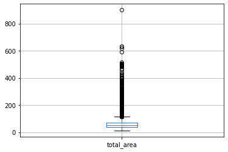

```python
data.boxplot('total_area')
```

Интересная картина складывается, максимальные значения уходят далеко за пределы усов. Значения от ~120 кв.м. и выше, есть и 900. Однако этих выбросов не тук уж много раз среднее больше медианы только на 8 метров. Посмотрим что это за интересные строки где прячутся дворцы.

```python
print(data.query('total_area > 300').sort_values(by='total_area')[['total_area','living_area','kitchen_area','last_price']])
```

```
       total_area  living_area  kitchen_area   last_price
19221       301.9        163.2          20.4   30000000.0
2243        304.0          NaN           NaN  130278280.0
7543        307.8        187.9          63.4  130000000.0
13397       309.7        199.0          14.3   19500000.0
793         310.0        250.0          50.0  135000000.0
...           ...          ...           ...          ...
5358        590.0        409.0         100.0   65000000.0
15651       618.0        258.0          70.0  300000000.0
3117        631.0          NaN          60.0  140000000.0
12859       631.2        322.3          19.5  140000000.0
19540       900.0        409.7         112.0  420000000.0

[61 rows x 4 columns]
```

Всего 61 квартира из 23699 - это 0,26 %.

Отбросим хоромы и посмотрим на диаграмму размаха

```python
data_new=data.query('total_area <= 300')
data_new['total_area'].describe()
```

```
count    23638.000000
mean        59.451020
std         30.540964
min         12.000000
25%         40.000000
50%         52.000000
75%         69.400000
max        300.000000
Name: total_area, dtype: float64
```

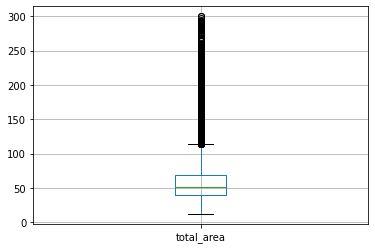

```python
data_new.boxplot('total_area')
```

Как видно не смотря на большой перепад между минимумом и максимумом основная масса квартир сосредоточена в небольшом диапазоне (межквартильный размах равен 29,4). Однако, квартиры выходящие за пределы усов с площадью > 113,5 продолжают влиять на среднее, которое по-прежнему выше медианы.

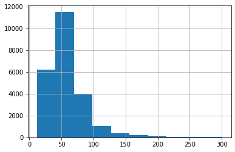

```python
data_new['total_area'].hist()
```

В то же время график приобрел более информативный вид. Хорошо видно, что почти в половине объявлений продаются квартиры площадью 40-69,4 кв.м.

Рассмотри теперь столбец с жилой площадью (living_area).

```python
data_new['living_area'].describe()
```

```
count    21748.000000
mean        34.035233
std         19.859903
min          2.000000
25%         18.600000
50%         30.000000
75%         42.200000
max        250.000000
Name: living_area, dtype: float64
```

Здесь медиана и среднее отличаются не существенно, хотя стандартное отклонение большое из-за разброса. Для начала нужно заменить нули, но так чтобы эта замена соотносилась с площадью всей квартиры, где заполнены все строки. Найдем соотношение медиан жилой часть к общей.

```python
liv_tot_rate=data_new['living_area'].median()/data_new['total_area'].median()
print(liv_tot_rate)
```

```
0.5769230769230769
```

```python
data_new.loc[data_new['living_area']==0,'living_area']=data_new['total_area']*liv_tot_rate
data_new['living_area'].describe()
```

```
count    21748.000000
mean        34.035233
std         19.859903
min          2.000000
25%         18.600000
50%         30.000000
75%         42.200000
max        250.000000
Name: living_area, dtype: float64
```

Интересно, что даже после преобразований по столбцу с общей площадью ещё где-то остались квартиры с малюсенькой жилой частью.

```python
print(data_new.sort_values(by='living_area')[['living_area','total_area']].head(10))
```

```
       living_area  total_area
21758          2.0        23.0
13915          2.0        52.0
23574          3.0       139.0
3242           3.0        41.0
17582          5.0        22.0
21943          5.4        77.6
16431          6.0        31.0
19251          6.5        33.0
23208          8.0        37.0
20994          8.0        50.6
```

В первых 4х строках скорее ошибка в формате. Выведем строки где площадь 52, 139, 41 и 77,6 м

```python
print(data_new.query('total_area==52')[['living_area','total_area']].head())
```

```
     living_area  total_area
87          30.0        52.0
175         31.0        52.0
416         30.5        52.0
794         29.7        52.0
913         32.0        52.0
```

```python
print(data_new.query('total_area==139')[['living_area','total_area']].head())
```

```
       living_area  total_area
7209          98.0       139.0
19867         75.0       139.0
21896         74.0       139.0
23574          3.0       139.0
```

```python
print(data_new.query('total_area==41')[['living_area','total_area']].head())
```

```
     living_area  total_area
56          18.1        41.0
377         28.4        41.0
423         18.7        41.0
614         16.8        41.0
737         15.4        41.0
```

```python
print(data_new.query('total_area==77.6')[['living_area','total_area']].head())
```

```
      living_area  total_area
1192        46.64        77.6
2368        51.90        77.6
2997        43.50        77.6
3921        44.60        77.6
6608        45.10        77.6
```

```python
data_new = data_new.copy()
```

```
count    21748.000000
mean        34.043675
std         19.854619
min          6.000000
25%         18.600000
50%         30.000000
75%         42.200000
max        250.000000
Name: living_area, dtype: float64
```

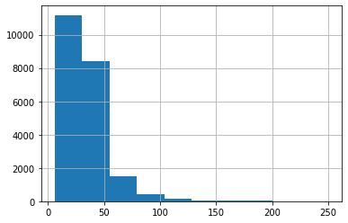

```python
data_new.loc[data_new['living_area']< 6,'living_area']=data_new.loc[data_new['living_area']< 6,'living_area']*10
print(data_new['living_area'].describe())
data_new['living_area'].hist()
```

Итак, работу со столбцом с living_area можно пока считать завершенной

```
Столбец kitchen_area (площадь кухни)
```

Рассмотрим теперь столбец с площадями кухонь kitchen_area.

```python
print(data_new.sort_values('kitchen_area')[['kitchen_area', 'total_area']])
```

```
       kitchen_area  total_area
20217           1.3        28.5
21419           2.0        20.0
906             2.0        27.0
6262            2.0        24.0
19642           2.0        14.0
...             ...         ...
23655           NaN        40.5
23663           NaN        88.0
23670           NaN        45.6
23679           NaN        35.0
23696           NaN        56.7

[23638 rows x 2 columns]
```

```python
kitch_tot_rate=data_new['kitchen_area'].median()/data_new['total_area'].median()
print(kitch_tot_rate)
```

```
0.175
```

Соотношение площади кухонь к общей равно 17%, так и будем считать.

```python
data_new.loc[data_new['kitchen_area']==0,'kitchen_area']=data_new['total_area']*kitch_tot_rate
data_new['kitchen_area'].describe()
```

```
count    21373.000000
mean        10.506684
std          5.673343
min          1.300000
25%          7.000000
50%          9.100000
75%         12.000000
max        107.000000
Name: kitchen_area, dtype: float64
```

Итак среднее значение не намного выше медианы даже при таком большом разбросе. Поэтому можно считать этот столбец обработанным.

```
Столбец last_price (последняя цена)
```

```python
data_new['last_price'].describe()
```

```
count    2.363800e+04
mean     6.306195e+06
std      7.770379e+06
min      1.219000e+04
25%      3.400000e+06
50%      4.620000e+06
75%      6.750000e+06
max      3.300000e+08
Name: last_price, dtype: float64
```

Хотя в этом столбце пропуски отсутствуют, первое что бросается в глаза это стандартное отклонение, превышающее среднюю величину и медиану, т.е. наблюдается большой разброс, который может негативно отразиться на достоверности исследования. Кроме того, минимальное значение очень уж маленькое, всего 12 тыс. Выведем строку с ним.

```python
print(data_new[data_new['last_price']==1.219000e+04])
```

```
      total_images  last_price  total_area first_day_exposition  rooms  \
8793             7     12190.0       109.0           2019-03-20      2

      ceiling_height  floors_total  living_area  floor  is_apartment  ...  \
8793            2.75          25.0         32.0     25          True  ...

      kitchen_area  balcony    locality_name  airports_nearest  \
8793          40.5      NaN  Санкт-Петербург           36421.0

     cityCenters_nearest  parks_around3000  parks_nearest  ponds_around3000  \
8793              9176.0               1.0          805.0               0.0

      ponds_nearest  days_exposition
8793            NaN              8.0

[1 rows x 22 columns]
```

```python
print(data_new[data_new['total_area']==109][['total_area', 'last_price']].head())
```

```
      total_area  last_price
2452       109.0  10500000.0
3614       109.0   8300000.0
5035       109.0  13200000.0
5198       109.0  13500000.0
7186       109.0  25000000.0
```

Так и есть, это квартира особенно выделяется своей дешевизной. Сделаем ей переоценку и построим диаграмму размаха.

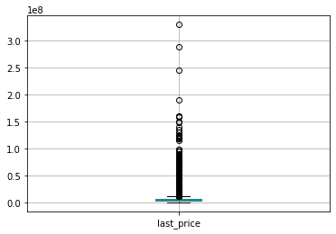

```python
data_new.loc[data_new['last_price']==1.219000e+04,'last_price']=data_new.loc[data_new['last_price']==1.219000e+04,'last_price']*1000
data_new.boxplot('last_price')
```

Как видно, в таблице есть квартиры цена на которые уходит далеко за верхний ус. Таких квартир не так много, учитывая межквартильный размах 3,35 млн., но они завышают среднее по сравнению с медианой и стандартное отклонение. Выведем на экран квартиры которые стоят свыше 40 млн вместе с площадями.

```python
print(data_new.query('last_price > 4.000000e+07').sort_values(by='last_price')[['last_price', 'total_area']])
```

```
        last_price  total_area
18832   40348248.0       284.0
21510   40488000.0       144.6
411     40662000.0       151.0
11710   41484000.0       160.0
17038   41900000.0       170.0
...            ...         ...
19155  160000000.0       243.0
8900   190870000.0       268.0
16461  245000000.0       285.7
22831  289238400.0       187.5
1436   330000000.0       190.0

[144 rows x 2 columns]
```

Таких квартир всего 144. Думаю исследование не потеряет если их исключить.

```python
data_new=data_new.query('last_price <= 4.000000e+07')
data_new['last_price'].describe()
```

```
count    2.349400e+04
mean     5.889960e+06
std      4.553019e+06
min      4.300000e+05
25%      3.400000e+06
50%      4.600000e+06
75%      6.700000e+06
max      4.000000e+07
Name: last_price, dtype: float64
```

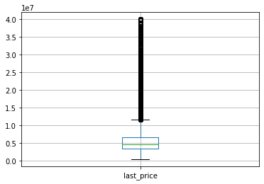

```python
data_new.boxplot('last_price')
```

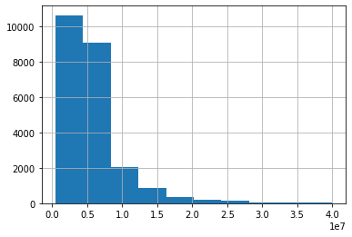

```python
data_new['last_price'].hist()
```

Ну вот и график уже стал ближе к распределению Пуассона. Стандартное отклонение снизилось на 41%, медиана практически не изменилась, среднее снизилось на 6,7%. Этот столбец можно также считать обработанным.

```
Столбец rooms (число комнат)
```

```python
print(data_new[data_new['rooms']==0][['rooms', 'total_area']].sort_values(by='total_area'))
```

```
       rooms  total_area
8886       0        15.5
9412       0        16.0
716        0        17.0
12996      0        18.0
8755       0        18.8
...      ...         ...
10008      0        44.2
13613      0        58.4
21227      0        71.0
3458       0        73.6
20082      0        98.4

[196 rows x 2 columns]
```

Всего 196 квартир не имеют комнат, это надо исправить. Например, вряд ли есть двушки там где площадь < 44кв.м. Проверим

```python
print(data_new.query('40<total_area<44')['rooms'].mean())
```

```
1.4365038560411312
```

```python
print(data_new.query('total_area==44')['rooms'].mean())
```

```
1.771014492753623
```

Так и есть примем что квартиры с площадью < 44 кв.м. - однушки, а там где площадь 44.2 - двушки

```python
data_new.loc[(data_new['total_area']<44) & (data_new['rooms']==0), 'rooms']=1
data_new.loc[(data_new['total_area']==44.2) & (data_new['rooms']==0), 'rooms']=2
```

Теперь найдем среднее для площади 58.4

```python
print(data_new.loc[data_new['total_area']==58.4, 'rooms'].mean())
```

```
2.4444444444444446
```

Будем и её считать двушкой

```python
data_new.loc[(data_new['total_area']==58.4) & (data_new['rooms']==0), 'rooms']=2
```

Найдем среднее число комнат в диапазоне 71-73.6

```python
print(data_new.query('71<=total_area<=73.6')['rooms'].mean())
```

```
2.78060413354531
```

Квартиры площадью 71 и 73.6 будем считать трешками

```python
data_new.loc[(data_new['total_area']==71) & (data_new['rooms']==0), 'rooms']=3
```

```python
data_new.loc[(data_new['total_area']==73.6) & (data_new['rooms']==0), 'rooms']=3
```

Осталась последняя бекомнатная квартира площадью 98.4 кв.м. Найдем среднее число конат для подобных квартир

```python
print(data_new.loc[data_new['total_area']==98.4, 'rooms'].mean())
```

```
2.5
```

И эту квартиру сделаем трешкой

```python
data_new.loc[(data_new['total_area']==98.4) & (data_new['rooms']==0), 'rooms']=3
```

```python
print(data_new[data_new['rooms']==0]['rooms'].count())
```

```
0
```

Итак безкомнатных квартир больше нет, обработку можно считать оконченной.

```python
data_new.shape[0]/data.shape[0]
```

```
0.9913498459850627
```

Таким образом, после обработки датафрейм сократился на 0,9%

К содержанию

### Добавление столбцов

#### Добавление столбца с ценой за 1 кв.м.

Разделим столбец last_price на total_area и сохраним данные в столбец sq_meter_prize

```python
data_new['sq_meter_price']=data_new['last_price']/data_new['total_area']
```

#### Добавление столбца с днем недели публикации

```python
data_new['weekday']=data_new['first_day_exposition'].dt.weekday
```

#### Добавление столбца месяцем публикации

```python
data_new['month']=data_new['first_day_exposition'].dt.month
```

#### Добавление столбца годом публикации

```python
data_new['year']=data_new['first_day_exposition'].dt.year
```

#### Добавление столбца с типом этажа квартиры

```python
def fl(row):
    if row['floor']==row['floors_total']:
        return 'последний'
    elif row['floor']==1:
        return 'первый'
    return 'другой'
data_new['floor_type']=data_new.apply(fl, axis=1)
```

#### Добавление расстояния до центра в км.

```python
data_new['km_center_dist']=data_new['cityCenters_nearest']/1000
data_new['km_center_dist']=data_new['km_center_dist'].round(0)
```

К содержанию

### Исследовательский анализ данных

#### Общая площадь

```
count    23494.000000
mean        58.645023
std         28.532584
min         12.000000
25%         40.000000
50%         52.000000
75%         69.000000
max        297.500000
Name: total_area, dtype: float64
```

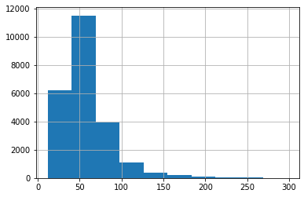

```python
data_new['total_area'].hist()
data_new['total_area'].describe()
```

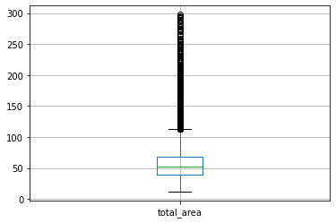

```python
data_new.boxplot('total_area')
```

Почти половина ~11500 (49%) квартир имеют площади 40-69 кв.м, ~6300 (27%) квартир с площадью от 12 до 40. Конечно вряд ли 12 кв.м. это квартира, это скорее комната в коммуналке или бараке. ~4000(17%) квартир с площадями от 69 до 90 кв.м. ~1000(4%) квартир с площадями от 90 до 125 кв.м. Квартир с площадью > 125 кв.м. ещё меньше (3%), но они влияют на среднюю величину и стандартное отклонение. Так среднее выше медианы на 13%, а стандартное отклонение почти равно межквартильному размаху (29 кв.м.).

#### Жилая площадь

```
count    21617.000000
mean        33.593818
std         18.729922
min          6.000000
25%         18.600000
50%         30.000000
75%         42.000000
max        225.900000
Name: living_area, dtype: float64
```

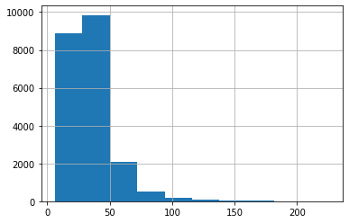

```python
data_new['living_area'].hist()
data_new['living_area'].describe()
```

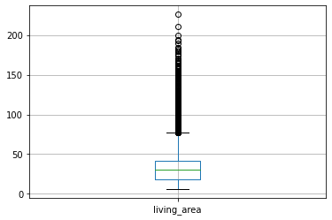

```python
data_new.boxplot('living_area')
```

Правая часть от максимума напоминает график с общей площадью, а левая сторона намного ближе к максимуму, т.е. с уменьшением общей площади жилая часть увеличивается (наверное так и есть, если всего 1 комната, коридоров нет, кухня совмещена с комнатой и представляет собой уголок 1 м). В данном случае 45% квартир имеют жилую часть 30-50 кв.м, ~40% квартир с площадью жилой части от 6 до 30. ~9% квартир с площадями от 50 до 60 кв.м. Квартир с площадью >60 кв.м. значительно меньше (6%), но они также влияют на среднюю величину и стандартное отклонение. Так среднее выше медианы на 12%.

#### Площадь кухни

```
count    21243.000000
mean        10.391290
std          5.300244
min          1.300000
25%          7.000000
50%          9.000000
75%         12.000000
max        100.700000
Name: kitchen_area, dtype: float64
```

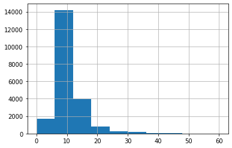

```python
data_new['kitchen_area'].hist(range=(0,60))
data_new['kitchen_area'].describe()
```

Итак, по площадям кухонь можно сказать что в основном (~65%) площадей находится от 6 до 12 кв.м. ~22% c площадями от 12 до 17 кв.м., ~10% кухонь-закутков (1,3-6) кв.м. Большие кухни (>17 кв.м.) в меньшинстве (3%).

#### Цена квартиры

```
count    23494.000000
mean         5.889960
std          4.553019
min          0.430000
25%          3.400000
50%          4.600000
75%          6.700000
max         40.000000
Name: last_price, dtype: float64
```

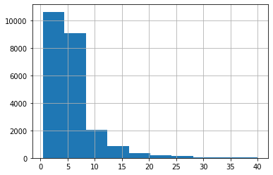

```python
data_new['last_price']/=1000000
data_new['last_price'].hist()
data_new['last_price'].describe()
```

График показвает, что ~46% квартир расположены в ценовой категории от 430 тыс. до 4 млн, ~38% - c ценой 4-8 млн., 8.5% квартир стоят 8-12 млн. Самых дорогих ещё меньше 7,5%.

#### Количество комнат

```
count    23494.000000
mean         2.056185
std          1.020828
min          1.000000
25%          1.000000
50%          2.000000
75%          3.000000
max         16.000000
Name: rooms, dtype: float64
```

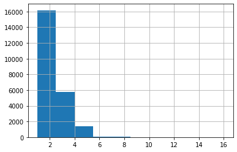

```python
data_new['rooms'].hist()
data_new['rooms'].describe()
```

На графике видно что однушек и двушек большинство (69,5%), трех-четырех комнатных - 24%, четырех-пяти комнатных - 5,5%, остальных - 1%.

#### Высота потолков

```
count    14374.000000
mean         2.720336
std          0.266417
min          2.000000
25%          2.502500
50%          2.650000
75%          2.800000
max          5.800000
Name: ceiling_height, dtype: float64
```

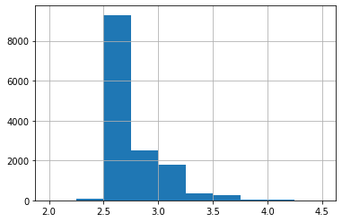

```python
data_new['ceiling_height'].hist(range=(2,4.5))
data_new['ceiling_height'].describe()
```

К содержанию

#### Этаж квартиры

```
count    23494.000000
mean         5.899762
std          4.896376
min          1.000000
25%          2.000000
50%          4.000000
75%          8.000000
max         33.000000
Name: floor, dtype: float64
```

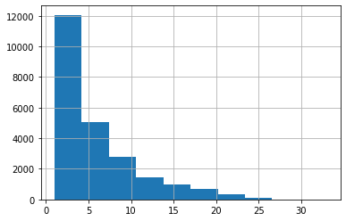

```python
data_new['floor'].hist()
data_new['floor'].describe()
```

Этажи выведены и можно сказать, что почти половина из них (51%) расположены с 1 по 4 этажи, 21% находятся на этажах с 4 по 7, 12% - с 7-11й, 6% - - с 11-13й, 4% - с 13-17й, квартиры на этажах от 17 до 33 - составляют 6%.

#### Тип этажа квартиры

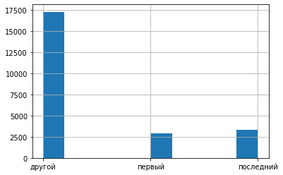

```python
data_new['floor_type'].hist()
```

73% квартир расположены ни на первом ни на последнем этажах 14% - на последнем 13% - на первом.

#### Общее количество этажей в доме

```
count    23409.000000
mean        10.704473
std          6.610281
min          1.000000
25%          5.000000
50%          9.000000
75%         16.000000
max         60.000000
Name: floors_total, dtype: float64
```

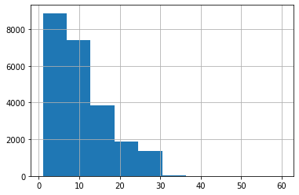

```python
data_new['floors_total'].hist()
data_new['floors_total'].describe()
```

38% квартир расположены в домах с числом этажей от 1 до 7. 31% квартир расположены в домах с числом этажей от 7 до 13. 16.5% квартир расположены в домах с числом этажей от 13 до 18. 8% квартир расположены в домах с числом этажей от 18 до 24. 5.5% квартир расположены в домах с числом этажей от 24 до 31. 1% квартир расположены в домах с числом этажей от 31 до 60.

#### Расстояние до центра города в метрах

```
count    17979.000000
mean     14286.371155
std       8594.871900
min        181.000000
25%       9436.000000
50%      13151.000000
75%      16336.000000
max      65968.000000
Name: cityCenters_nearest, dtype: float64
```

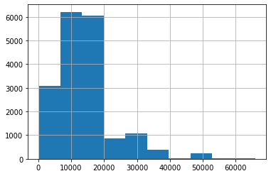

```python
data_new.query('cityCenters_nearest>0')['cityCenters_nearest'].hist()
data_new.query('cityCenters_nearest>0')['cityCenters_nearest'].describe()
```

#### Расстояние до ближайшего аэропорта

```
count    17958.000000
mean     28815.307551
std      12683.236837
min       6450.000000
25%      18518.000000
50%      26766.000000
75%      37364.000000
max      84869.000000
Name: airports_nearest, dtype: float64
```

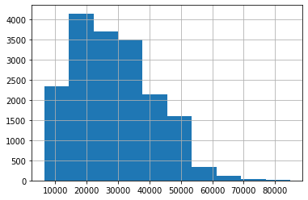

```python
data_new.query('airports_nearest>0')['airports_nearest'].hist()
data_new.query('airports_nearest>0')['airports_nearest'].describe()
```

Наибольшее число квартир (около 23 %) расположены на расстоянии от 14000 до 22000 м от аэропорта. 21 % квартир удалены от аэропорта на 22000-30000 м. 19% - 30000-38000 м. 13% квартир ближе всех к аэропорту (6450-14000м). 12% квартир уже намного дальше - 38000-46000 м. 9% - на расстоянии 46000-54000 м. 2% - на расстоянии 54000-62000 м. Остальные - 1% - самые удаленные (62000 - 84869м).

К содержанию

#### Расстояние до ближайшего парка

```
count    7927.000000
mean      492.665573
std       342.522060
min         1.000000
25%       289.000000
50%       456.000000
75%       613.000000
max      3190.000000
Name: parks_nearest, dtype: float64
```

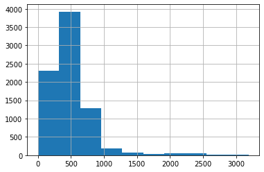

```python
data_new.query('parks_nearest>0')['parks_nearest'].hist()
data_new.query('parks_nearest>0')['parks_nearest'].describe()
```

```python
print(data_new.query('parks_nearest==1')[['parks_nearest','parks_around3000']])
```

```
       parks_nearest  parks_around3000
14624            1.0               1.0
```

Как видно, одна из квартир расположена в 1 метре от парка, проверить это сложно, но если так, кому-то повезло.

Что же касается графика, то тут привычное Пуассоновское распределение с одним максимумом (49%) на расстоянии 300-600 м, 29% - ближе всех к парку от 1 до 300 м, 17% удалены на 600-900 м, 2,5% находятся в пределах 900-1200 м. Оставшиеся 2,5% дальше всех (1200-3190м).

#### День публикации объявления

```
count    23494.000000
mean         2.569039
std          1.789472
min          0.000000
25%          1.000000
50%          3.000000
75%          4.000000
max          6.000000
Name: weekday, dtype: float64
```

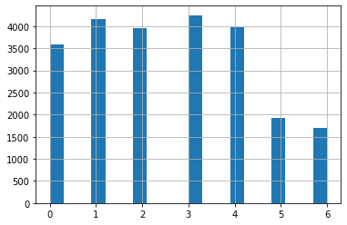

```python
data_new['weekday'].hist(bins=20)
data_new['weekday'].describe()
```

Как видно из графика активность публикаций особенно высока во вторник и четверг (~19%), ~17% квартир выставляются в среду и пятницу. Немного меньше объявлений появляется в понедельник 15% (наверное логично, кто-то ещё не до конца вошел в трудовые будни после выходных). В выходные таким серьезным делом как продажа квартиры заняты значительно реже (7% - в субботу и 6% - в воскресенье).

#### Месяц публикации объявления

```
count    23494.000000
mean         6.399208
std          3.490791
min          1.000000
25%          3.000000
50%          6.000000
75%         10.000000
max         12.000000
Name: month, dtype: float64
```

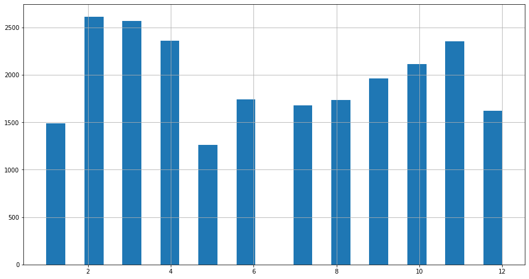

```python
data_new['month'].hist(bins=24, figsize=(15,8))
data_new['month'].describe()
```

Рассмотрим с начала года, с января, где после праздников активность подачи объявлений совсем невысокая (6%), но зато после февраль и март бьют рекорды (~11%), затем в апреле происходит снижение на 1% (10%) и в мае происходит провал до минимума (5%). В июне снова рост до 7%, в июле чуть ниже, но тоже около 7%. В августе чуть заметный рост, примерно до июньского уровня. После августа рост уже заметнее: в сентябре до 8%, 9% объявлений - в октябре, в ноябре продажи поднимаются до апрельского уровня (10%), а в декабре опять провал до ~7% (что вероятно потому, что обычно на конец года не оставляют важных дел)

#### Изучение сроков продаж квартир

```
count    20361.000000
mean       179.795491
std        218.837288
min          1.000000
25%         45.000000
50%         95.000000
75%        229.000000
max       1580.000000
Name: days_exposition, dtype: float64
```

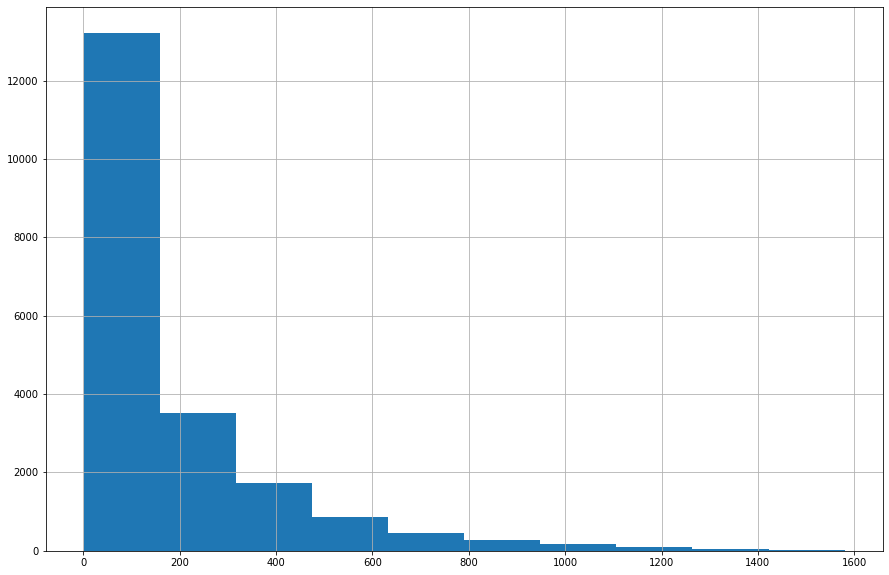

```python
data_new['days_exposition'].hist(figsize=(15, 10))
data_new['days_exposition'].describe()
```

```
count    17358.000000
mean       104.524369
std         89.331554
min          1.000000
25%         37.000000
50%         74.000000
75%        153.000000
max        364.000000
Name: days_exposition, dtype: float64
```

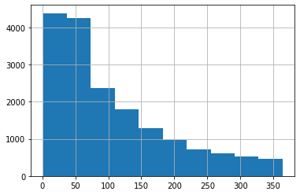

```python
data_new.query('days_exposition<=365')['days_exposition'].hist()
data_new.query('days_exposition<=365')['days_exposition'].describe()
```

#### Факторы влияющие на стоимость объекта

Для исследования влияния на стоимость объекта:

[output not shown]

матрицу диаграмм рассеяния.

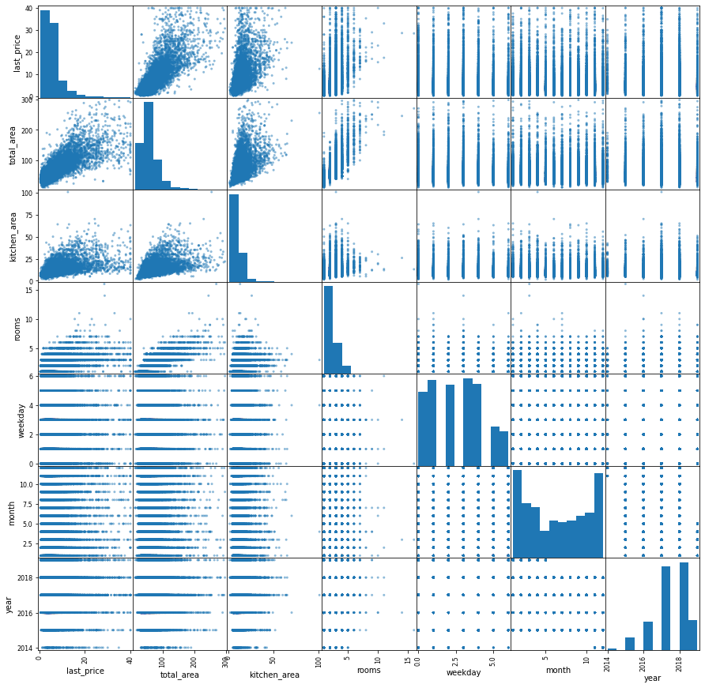

```python
pd.plotting.scatter_matrix(data_new[['last_price', 'total_area', 'kitchen_area', 'rooms', 'floor_type', 'weekday', 'month', 'year']], figsize=(15,15));
```

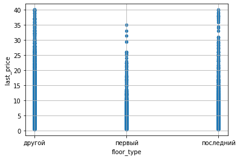

```python
data_new.plot(x='floor_type', y='last_price', kind='scatter', grid=True);
```

#### Cредняя цена одного квадратного метра в 10 населённых пунктах с наибольшим числом объявлений

```python
mean_meter_price=data_new.pivot_table(index='locality_name', values='sq_meter_price', aggfunc=['count', 'mean'])
mean_meter_price.columns=['adv_count', 'mean_meter_price']
print(mean_meter_price.sort_values(by='adv_count', ascending=False).head(10))
```

```
                   adv_count  mean_meter_price
locality_name
Санкт-Петербург        15520     111730.353734
поселок Мурино           556      85681.762601
поселок Шушары           440      78677.364217
Всеволожск               398      68654.473986
Пушкин                   367     103130.851744
Колпино                  337      75333.295801
поселок Парголово        327      90175.913458
Гатчина                  307      68746.146763
деревня Кудрово          299      92473.547576
Выборг                   237      58141.909153
```

Таким образом, расчеты показали что среди выбранных населенных пунктов самая высокая средняя цена за 1 кв. метр в Санкт-Петербурге (111730 р.), самая низкая - в Выборге (58142 р.)

#### Cредняя цена объекта на км расстояния до центра.

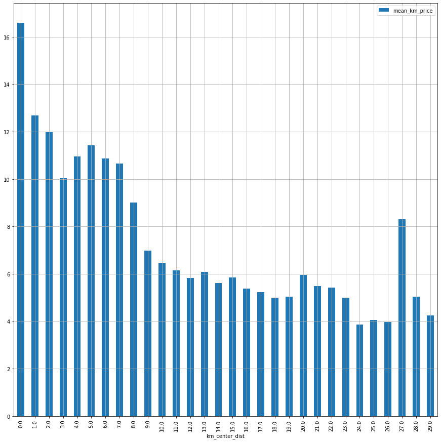

```python
sp_price_km=data_new.loc[data_new['locality_name']=='Санкт-Петербург', ['last_price', 'km_center_dist']]
sp_price_km=sp_price_km.pivot_table(index='km_center_dist', values='last_price')
sp_price_km.columns=['mean_km_price']
sp_price_km.plot(kind='bar', grid=True, figsize=(15,15))
```

Ну вот и построен последний график, помогающий ответить на главный вопрос о рыночной стоимости жилья в Санкт-Петербурге. Конечно, он далек от идеала, но всё же тенденцию к отрицательной корреляции цены от расстояния до центра нельзя не отметить. Максимальные цены на квартиры, как и следовало ожидать, находятся в центре города (16,6 млн.). От нуля до 3 км до центра просходит равномерное снижение стоимости до 10 млн. , далее на 4х км. идет непонятный скачок до 11 млн. возможно связанный с влиянием других факторов (близость метро, парка и т.д.), после через 1 км ещё увеличение до 11,5 млн. Затем, снижение с чередование по скорости с небольшими скачками до 5 млн. (это 18-19 км.). Затем, как это ни странно, скачок до 6 млн. на 20-ти км., и снова снижение до минимума (3.9 млн.) на 24 км. далее (с 25-26) цена сохраняется в районе 4 млн. А на 27-м км.(!) скачок вдвое до 8,3млн., и затем спад до 5 млн. (28км) и до 4,3 млн.(до29 км).

К содержанию